# Cflo-healthy-controls (TC7)

Biplabendu Das

14 February, 2022

```r
# SAMPLE NAME
## specify focal sample for analyis
sample.name <- "cflo_control"

# SCRIPT NAME
## specify the name of the script (folder) where figures will be saved
script.name <- "01_general_patterns_of_gene_exp"

# eJTK OUTPUT
## Set GammaP threshold below which genes are classified as rhythmic
gamma.pval = 0.05
```

```r
# LOAD DATABASES (TC7)
## 1. TC7_ejtk.db
# writeLines("Loading 'TC7_ejtk' database that contains all ejtk-output for TC7")
ejtk.db <- dbConnect(RSQLite::SQLite(),
                   paste0(path_to_repo, "/data/databases/TC7_ejtk.db"))
# which tables are in the database
# src_dbi(ejtk.db)

## 2. TC7_data.db
# writeLines("Loading 'TC7_data' database that contains all expression data for TC7")
data.db <- dbConnect(RSQLite::SQLite(),
                     paste0(path_to_repo, "/data/databases/TC7_data.db"))
# src_dbi(data.db)
```

## Overview/Goals

Using time-course RNASeq data from healthy Cflo forager heads:

- identify the list of “expressed” genes (≥ 1 FPKM for at least one time point),
- identify list of rhythmic genes (24h, 12h, and 08h)
- characterize their daily expression patterns
- find biological processes enriched in these rhythmic genesets
- compare rhythmic genes in heads to those identified in brains

## Part 1: General patterns of gene expression

### 1.1 Non-expressed genes

- Genes that have NO expression in ant heads (FPKM = 0 at all time points)

```r
# which genes have zero expression at all time points
not.expressed <-
  tbl(data.db, paste0(sample.name ,"_fpkm")) %>%
  collect() %>%
  filter_at(vars(starts_with("Z")), all_vars(. == 0)) %>%
  pull(gene_name)

writeLines("How many genes have zero expression in healthy Cflo heads at all time points?")
```

```
## How many genes have zero expression in healthy Cflo heads at all time points?
```

```r
length(not.expressed)
```

```
## [1] 1624
```

```r
writeLines("Which GO terms are enriched in this set of non-expressed genes?")
```

```
## Which GO terms are enriched in this set of non-expressed genes?
```

```
## [1] "Loading annotation file for Camponotus floridanus"
## [1] "Done."
## [1] "Number of genes in background geneset: 13813"
## [1] "Number of genes in the test set: 1624"
## [1] "--------------------------------"
## [1] "Number of GO terms in background geneset: 2000"
## [1] "Number of GO terms (at least 5genes) in background geneset: 406"
## [1] "Number of GO terms (at least 5genes) in test set: 35"
## [1] "Testing for enrichment..."
```

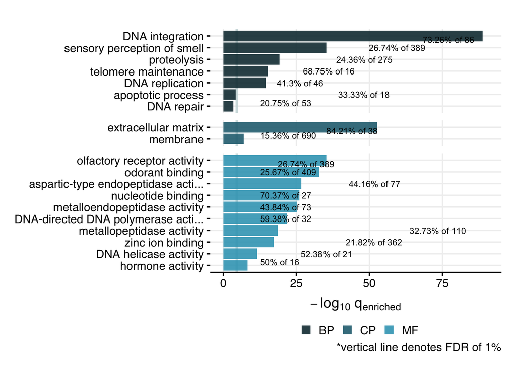

```r
not.expressed %>%
  go_enrichment(.,
                function.dir = path_to_repo,
                org = "cflo",
                bg = "all") %>%  # enrichment against all ophio_cflo genes in the genome
  go_enrichment_plot(clean = "no",
                     function.dir = path_to_repo)
```

```r
# save the processes that are enriched
not.expressed.process <-
  not.expressed %>%
  go_enrichment(.,
                function.dir = path_to_repo,
                org = "cflo",
                bg = "all") %>%
  select(GO, GO_desc, over_under, adj_pVal) %>%
  filter(over_under == "over") %>%
  filter(adj_pVal < 0.05) %>%
  pull(GO)
```

```
## [1] "Loading annotation file for Camponotus floridanus"
## [1] "Done."
## [1] "Number of genes in background geneset: 13813"
## [1] "Number of genes in the test set: 1624"
## [1] "--------------------------------"
## [1] "Number of GO terms in background geneset: 2000"
## [1] "Number of GO terms (at least 5genes) in background geneset: 406"
## [1] "Number of GO terms (at least 5genes) in test set: 35"
## [1] "Testing for enrichment..."
```

Are these the same genes/proecesses that were either not- or lowly-expressed in Cflo brains?

```r
tc5.path_to_repo <- "/Users/biplabendudas/Documents/GitHub/Das_et_al_2021"

## 3. TC5_data.db
tc5.data.db <- dbConnect(RSQLite::SQLite(),
                     paste0(tc5.path_to_repo, "/data/TC5_data.db"))

src_dbi(tc5.data.db)
```

```
## src:  sqlite 3.29.0 [/Users/biplabendudas/Documents/GitHub/Das_et_al_2021/data/TC5_data.db]
## tbls: annot_fpkm, annot_fpkm_meta, blastp_rhy_summary, ejtk_12h_all,
##   ejtk_8h_all, ejtk_all, expressed_genes, expressed_genes_meta, ophio_all_DEG,
##   ophio_biting_control, ophio_dead_biting, TC5_degs_all, zscore_for, zscore_nur
```

```r
# save the non-expressed genes in forager brains
non.expressed.for <-
  tbl(tc5.data.db, paste0("annot_fpkm")) %>%
  select(gene_name,X2F:X24F) %>%
  collect() %>%
  na.omit() %>%
  filter_at(vars(starts_with("X")), all_vars(. == 0)) %>%
  pull(gene_name)

# save the processes enriched
non.expressed.for.process <-
  non.expressed.for %>%
  go_enrichment(.,
                function.dir = path_to_repo,
                org = "cflo",
                bg = "all") %>%
  select(GO, GO_desc, over_under, adj_pVal) %>%
  filter(over_under == "over") %>%
  filter(adj_pVal < 0.05) %>%
  pull(GO)
```

```
## [1] "Loading annotation file for Camponotus floridanus"
## [1] "Done."
## [1] "Number of genes in background geneset: 13813"
## [1] "Number of genes in the test set: 1383"
## [1] "--------------------------------"
## [1] "Number of GO terms in background geneset: 2000"
## [1] "Number of GO terms (at least 5genes) in background geneset: 406"
## [1] "Number of GO terms (at least 5genes) in test set: 38"
## [1] "Testing for enrichment..."
```

```
## [1] "Loading annotation file for Camponotus floridanus"
## [1] "Done."
## [1] "Number of genes in background geneset: 13813"
## [1] "Number of genes in the test set: 1383"
## [1] "--------------------------------"
## [1] "Number of GO terms in background geneset: 2000"
## [1] "Number of GO terms (at least 5genes) in background geneset: 406"
## [1] "Number of GO terms (at least 5genes) in test set: 38"
## [1] "Testing for enrichment..."
```

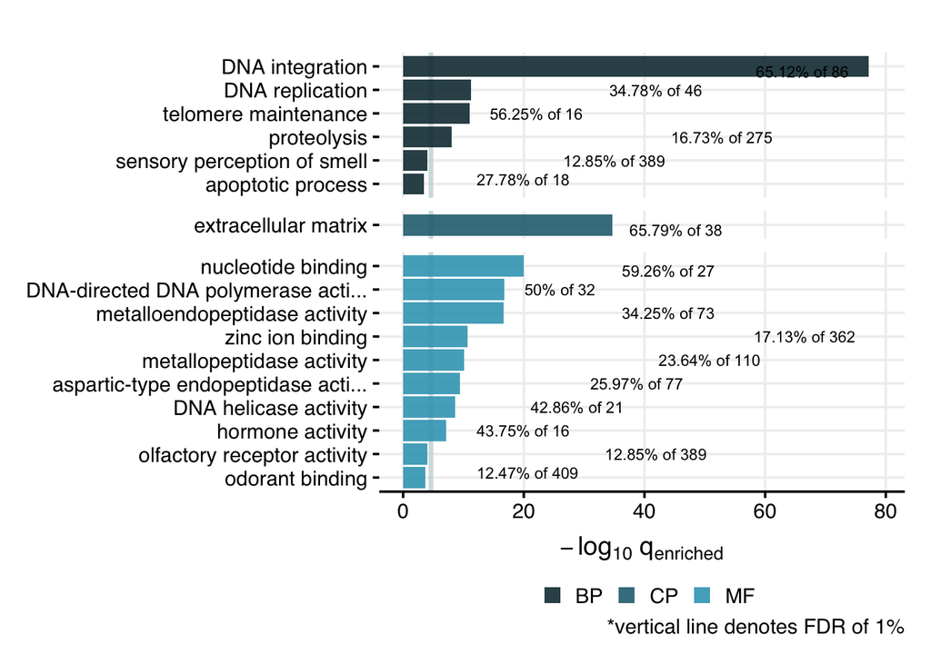

```r
# plot the results
non.expressed.for %>%
  go_enrichment(.,
                function.dir = path_to_repo,
                org = "cflo",
                bg = "all") %>%
  go_enrichment_plot(clean = "no", function.dir = path_to_repo)
```

Now, perform Fisher’s exact tests to check for significant overlap

1. Genes not expressed

```r
set.1 <- not.expressed # forager heads
set.2 <- non.expressed.for # forager brains

tot.genes <- 13808 # all genes in the Cflo genome

# To create the contingency table for module-7 (set-1) and for.rhy (set-2), we will need the following information:
# genes that are in both sets
overlapping.genes <- intersect(set.1, set.2) %>% length()
# genes in set-1 but not in set-2
set.1.not.set.2 <- setdiff(set.1, set.2) %>% length()
# genes in set-2 but not in set-1
set.2.not.set.1 <- setdiff(set.2, set.1) %>% length()
# background genes not in set-1 or set-2
not.set.1.set.2 <- tot.genes - (union(set.1, set.2) %>% unique() %>% length())

# Contingency table for set.1 and set.2
test.table <-
  data.frame(
    in.set.2 = c(overlapping.genes, set.2.not.set.1),
    not.set.2 = c(set.1.not.set.2, not.set.1.set.2)
  )
rownames(test.table) <- c("in.set.1", "not.set.1")

# take a look at the contingency table
test.table
```

```
##           in.set.2 not.set.2
## in.set.1      1172       452
## not.set.1      211     11973
```

```r
# fisher test
fisher.test(test.table)
```

```
##
##  Fisher's Exact Test for Count Data
##
## data:  test.table
## p-value < 2.2e-16
## alternative hypothesis: true odds ratio is not equal to 1
## 95 percent confidence interval:
##  123.4159 175.2381
## sample estimates:
## odds ratio
##   146.5402
```

### 1.2 Expressed genes

- Genes that are expressed in ant heads (≥ 1 FPKM for at least one time point)

```r
# which genes are expressed in ant heads?
expressed <-
  tbl(data.db, paste0(sample.name,"_expressed_genes")) %>%
  filter(expressed=="yes") %>%
  collect() %>%
  pull(gene_name)

writeLines("How many genes are expressed in healthy Cflo heads?")
```

```
## How many genes are expressed in healthy Cflo heads?
```

```r
length(expressed)
```

```
## [1] 10104
```

> Note, this set of 10104 genes will be used as the background geneset for performing GO/PFAM enrichments for our genesets of interest.

## Part 2: Diurnal rhythms in gene expression

### 2.1 Load rhythmic genesets

```r
## Load all the rhythmic genesets
## Note, ordered according to their p-value; highly rhythmic at the top.

# Circadian genes (period = 24h)
## get the gene-names for sig. 24h-rhythmic genes
rhy.24 <-
  tbl(ejtk.db, paste0(sample.name,"_zscores_24h")) %>%
  filter(GammaP < gamma.pval) %>%
  select(ID, GammaP) %>% collect() %>% arrange(GammaP) %>%
  select(ID) %>% pull()

# Ultradian genes (period = 12h)
## get the gene-names for sig. 12h-rhythmic genes
rhy.12 <-
  tbl(ejtk.db, paste0(sample.name,"_zscores_12h")) %>%
  filter(GammaP < gamma.pval) %>%
  select(ID, GammaP) %>% collect() %>% arrange(GammaP) %>%
  select(ID) %>% pull()

# Ultradian genes (period = 08h)
## get the gene-names for sig. 08h-rhythmic genes
rhy.08 <-
  tbl(ejtk.db, paste0(sample.name,"_zscores_08h")) %>%
  filter(GammaP < gamma.pval) %>%
  select(ID, GammaP) %>% collect() %>% arrange(GammaP) %>%
  select(ID) %>% pull()

writeLines(paste0("How many sig. rhythmic genes are there in healthy Cflo heads? (GammaP < ",gamma.pval, ")"))
```

```
## How many sig. rhythmic genes are there in healthy Cflo heads? (GammaP < 0.05)
```

```r
rhy.genes <- list(rhy.24,rhy.12,rhy.08)
names(rhy.genes) <- paste0(sample.name, c("_24h", "_12h", "_08h"))
sapply(rhy.genes,length)
```

```
## cflo_control_24h cflo_control_12h cflo_control_08h
##              852              548              881
```

### 2.2 Hierarchical clustering and plotting heatmaps

- perform hierarchical clustering of the rhythmic genes,
- plot time-course heatmaps for the clustered rhythmic geneset,
- identify the day-peaking and night-peaking clusters visually.

```
## Clustering and plotting heatmaps for cflo_control_24h
```

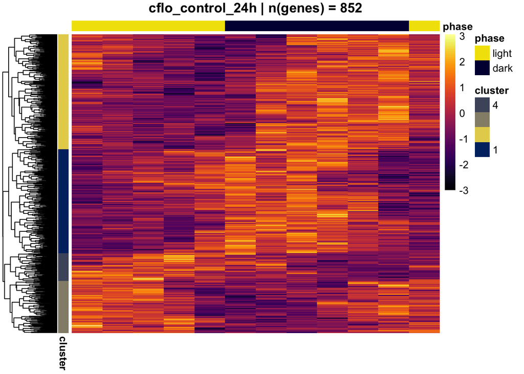

```
## Clustering and plotting heatmaps for cflo_control_12h
```

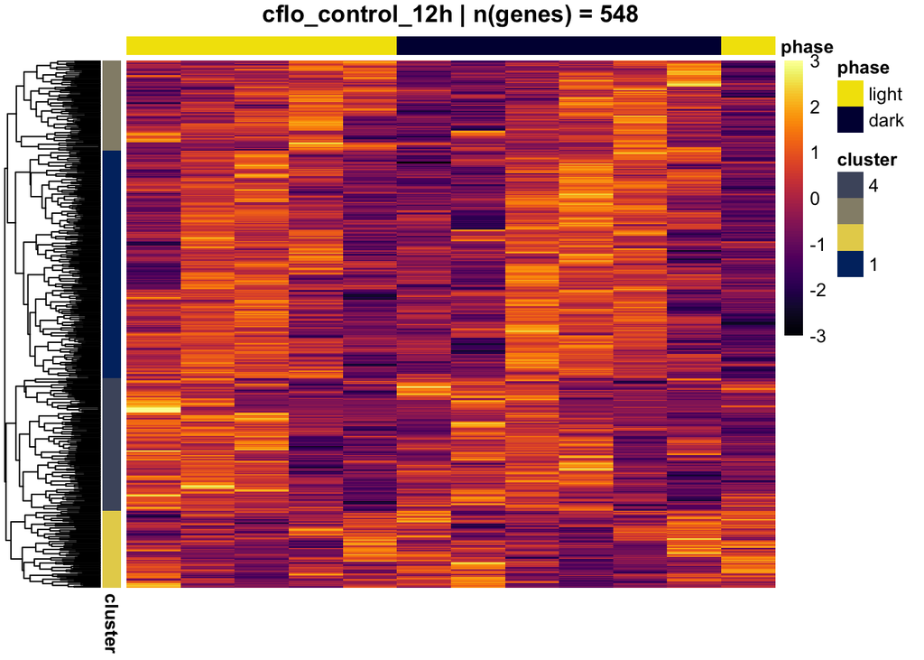

```
## Clustering and plotting heatmaps for cflo_control_08h
```

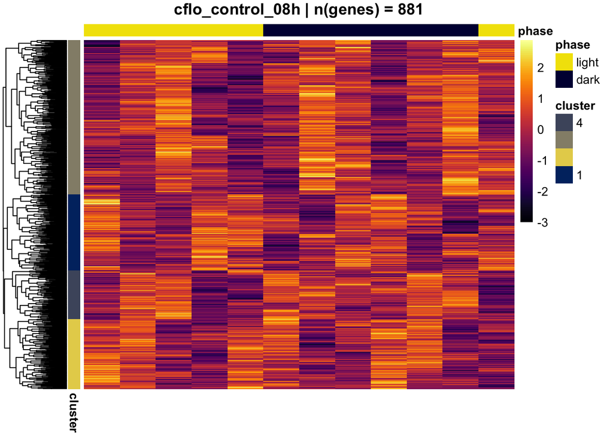

```r
## load zscore dataset
zscore.dat <- data.db %>% tbl(., paste0(sample.name,"_zscores")) %>% collect()

# make a list to save the cluster information
my_gene_col <- list()

# Filter the zscores to keep only rhythmic genes
for (i in 1:length(rhy.genes)){

  writeLines(paste0("Clustering and plotting heatmaps for ", names(rhy.genes)[i]))

  # filter the zscores for the rhythmic geneset
  zscore.rhy <-
    zscore.dat %>%
    filter(gene_name %in% rhy.genes[[i]]) %>% # either (rhy.8, rhy.12, or rhy.24)
    as.data.frame()

  # Set genes as rownames and convert it into a matrix
  rownames(zscore.rhy) = zscore.rhy$gene_name
  zscore.rhy <- as.matrix(zscore.rhy[-1])


  # Hierarchical clustering the geneset
  my_hclust_gene <- hclust(dist(zscore.rhy), method = "complete")


  # Make annotations for the heatmaps
  my_gene_col[[i]] <- cutree(tree = as.dendrogram(my_hclust_gene), k = 4) # four clusters
  my_gene_col[[i]] <- data.frame(cluster = my_gene_col[[i]])


  # I’ll add some column annotations and create the heatmap.
    # Annotations for:
    # 1. Is the sample collected during the light or dark phase?
  my_sample_col <- data.frame(phase = rep(c("light", "dark", "light"), c(5,6,1)))
  row.names(my_sample_col) <- colnames(zscore.rhy)

  # Manual color palette
  my_colour = list(
    phase = c(light = "#F2E205", dark = "#010440"),
    cluster = viridis::cividis(100)[c(10,90,60,30)])

  # Color scale
  my.breaks = seq(-3, max(zscore.rhy), by=0.06)
  # my.breaks = seq(min(zscore.rhy), max(zscore.rhy), by=0.06)

  # Let's plot!
  pheatmap(zscore.rhy, show_rownames = F, show_colnames = F,
                           annotation_row = my_gene_col[[i]],
                           annotation_col = my_sample_col,
                           # cutree_rows = 4,
                           cutree_cols = 2,
                           annotation_colors = my_colour,
                           border_color=FALSE,
                           cluster_cols = F,
                           breaks = my.breaks,
                           ## color scheme borrowed from:
                           color = inferno(length(my.breaks) - 1),
                           # treeheight_row = 0,
                           # treeheight_col = 0,
                           # remove the color scale or not
                           main = paste0(names(rhy.genes)[i],
                                         " | n(genes) = ",
                                         length(rhy.genes[[i]])),
                           ## annotation legend
                           annotation_legend = T,
                           ## Color scale
                           legend = T)

  }
```

### 2.3 Which processes are enriched in the rhytmic genesets?

#### 2.3.1 24h-rhythmic genes

- that peak during the day (day-peaking clusters) and night (night-peaking clusters);
- plot the enrichment results.

From eye-balling the heatmap

- day-peaking cluster: cluster-3, cluster-4
- night-peaking cluster: cluster-1, cluster-2

```r
writeLines("runnning GO enrichment for day-peaking clusters")
```

```
## runnning GO enrichment for day-peaking clusters
```

```r
## day-peaking | cluster 3 & 4 ##
rhy.24.daypeaking.cluster.3.4 <-
  my_gene_col[[1]] %>%
  rownames_to_column(var = "gene") %>%
  filter(cluster %in% c(3,4)) %>%
  pull(gene) %>%
  # run enrichment analysis
  go_enrichment(.,
                function.dir = path_to_repo,
                org = "cflo",
                bg = expressed) #%>%  # enrichment against all expressed ophio_cflo genes
```

```
## [1] "Loading annotation file for Camponotus floridanus"
## [1] "Done."
## [1] "Number of genes in background geneset: 10104"
## [1] "Number of genes in the test set: 227"
## [1] "--------------------------------"
## [1] "Number of GO terms in background geneset: 1979"
## [1] "Number of GO terms (at least 5genes) in background geneset: 388"
## [1] "Number of GO terms (at least 5genes) in test set: 10"
## [1] "Testing for enrichment..."
```

```r
writeLines("plotting the enriched GOs for day-peaking clusters")
```

```
## plotting the enriched GOs for day-peaking clusters
```

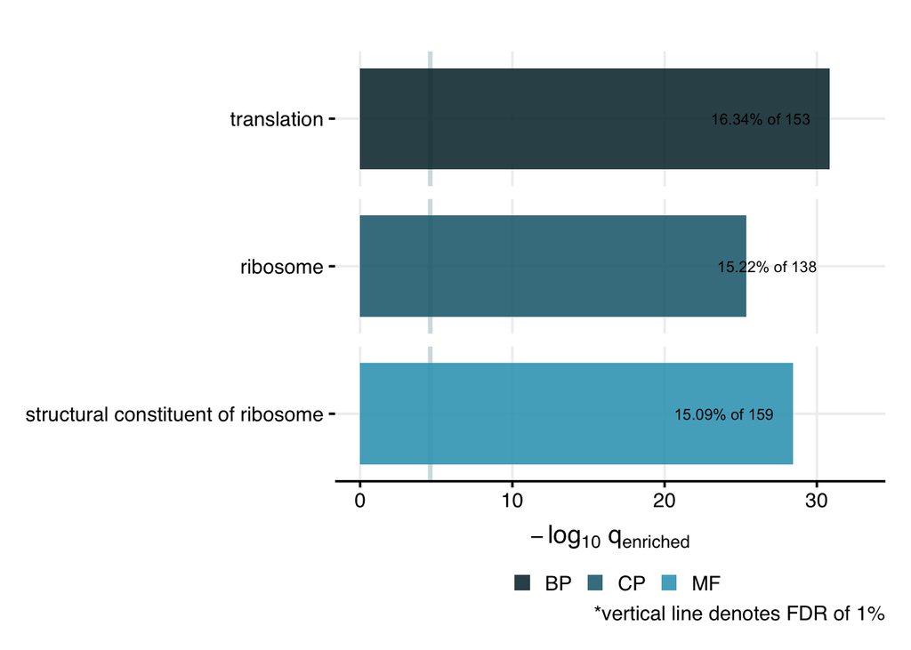

```r
rhy.24.daypeaking.cluster.3.4 %>%
  go_enrichment_plot(clean = "no",
                     function.dir = path_to_repo,
                     fdr = 5)
```

```r
# # view the results
# rhy.24.daypeaking.cluster.3.4 %>% head() %>% view()


writeLines("runnning GO enrichment for night-peaking clusters")
```

```
## runnning GO enrichment for night-peaking clusters
```

```r
## night-peaking | cluster 1 & 2 ##
rhy.24.nightpeaking.cluster.1.2 <-
  my_gene_col[[1]] %>%
  rownames_to_column(var = "gene") %>%
  filter(cluster %in% c(1,2)) %>%
  pull(gene) %>%
  # stacked.zplot_tc7()
  go_enrichment(.,
                function.dir = path_to_repo,
                org = "cflo",
                bg = expressed)
```

```
## [1] "Loading annotation file for Camponotus floridanus"
## [1] "Done."
## [1] "Number of genes in background geneset: 10104"
## [1] "Number of genes in the test set: 625"
## [1] "--------------------------------"
## [1] "Number of GO terms in background geneset: 1979"
## [1] "Number of GO terms (at least 5genes) in background geneset: 388"
## [1] "Number of GO terms (at least 5genes) in test set: 32"
## [1] "Testing for enrichment..."
```

```r
writeLines("plotting the enriched GOs for night-peaking clusters")
```

```
## plotting the enriched GOs for night-peaking clusters
```

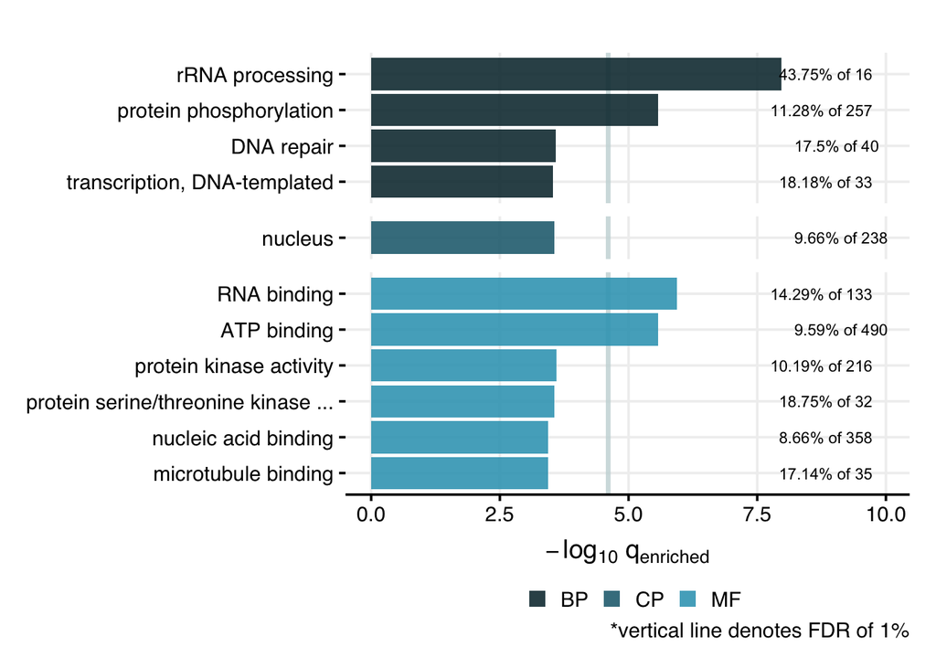

```r
# plot the enriched GOs
rhy.24.nightpeaking.cluster.1.2 %>%
  go_enrichment_plot(clean = "no",
                     function.dir = path_to_repo,
                     fdr = 5)
```

```r
# # view the results
# rhy.24.nightpeaking.cluster.1.2 %>% head() %>% view()
```

#### 2.3.2 12h-rhythmic genes

> We did not find any enriched GOs for 12h-rhythmic genes

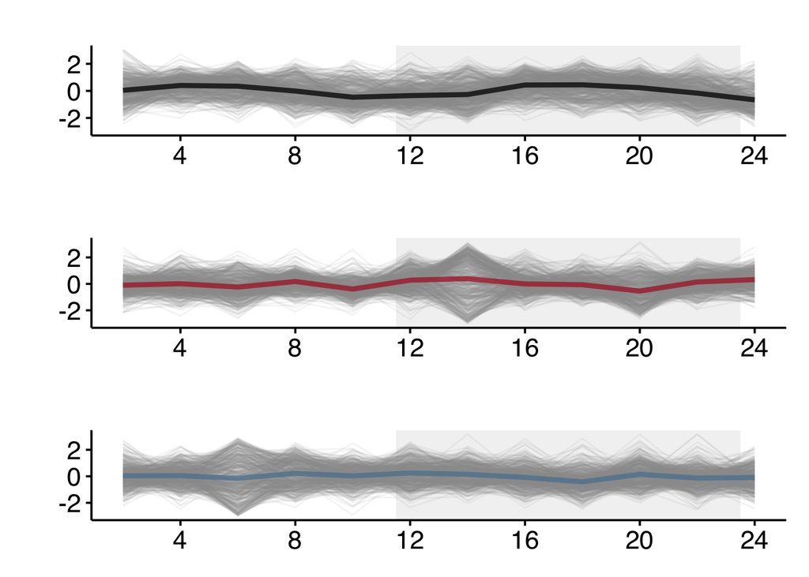

```r
my_gene_col[[2]] %>%
  rownames_to_column(var = "gene") %>%
  pull(gene) %>%
  stacked.zplot_tc7() %>%
  multi.plot(rows = 3,cols = 1)
```

#### 2.3.3 08h-rhyhtmic genes

Run GO enrichment for:

- all of them (What are these genes?) | result: 1-BP and 4-MF sig. enriched
- Cluster 1 (one peak is around ZT16-18) | result: 1-BP and 3-MF sig. enriched
- Cluster 3 (one peak is around ZT6) | result: 1-MF sig. enriched

```r
writeLines("runnning GO enrichment for all 08h-rhythmic genes")
```

```
## runnning GO enrichment for all 08h-rhythmic genes
```

```
## [1] "Loading annotation file for Camponotus floridanus"
## [1] "Done."
## [1] "Number of genes in background geneset: 10104"
## [1] "Number of genes in the test set: 881"
## [1] "--------------------------------"
## [1] "Number of GO terms in background geneset: 1979"
## [1] "Number of GO terms (at least 5genes) in background geneset: 388"
## [1] "Number of GO terms (at least 5genes) in test set: 42"
## [1] "Testing for enrichment..."
```

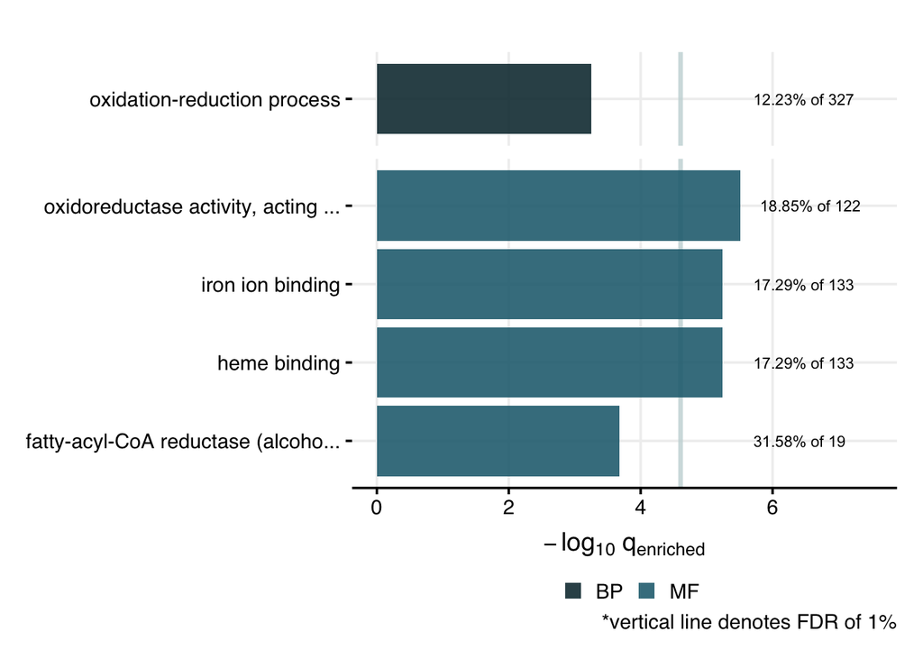

```r
# all genes
# rhy.8.all.genes <-
  my_gene_col[[3]] %>%
    rownames_to_column(var = "gene") %>%
    # filter(cluster %in% c(2,3)) %>%
    pull(gene) %>%
    # run enrichment analysis
    go_enrichment(.,
                  function.dir = path_to_repo,
                  org = "cflo",
                  bg = expressed) %>%  # enrichment against all expressed ophio_cflo genes
    go_enrichment_plot(clean = "no",
                       function.dir = path_to_repo)
```

```r
writeLines("runnning GO enrichment for 08h-rhythmic genes in Cluster 01")
```

```
## runnning GO enrichment for 08h-rhythmic genes in Cluster 01
```

```
## [1] "Loading annotation file for Camponotus floridanus"
## [1] "Done."
## [1] "Number of genes in background geneset: 10104"
## [1] "Number of genes in the test set: 192"
## [1] "--------------------------------"
## [1] "Number of GO terms in background geneset: 1979"
## [1] "Number of GO terms (at least 5genes) in background geneset: 388"
## [1] "Number of GO terms (at least 5genes) in test set: 8"
## [1] "Testing for enrichment..."
```

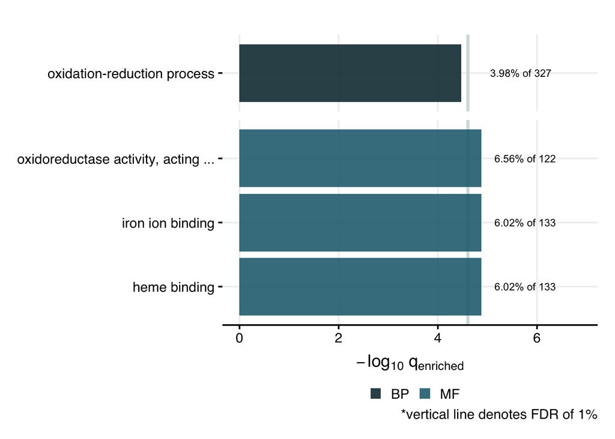

```r
# cluster 1
# rhy.8.cluster.1 <-
  my_gene_col[[3]] %>%
    rownames_to_column(var = "gene") %>%
    filter(cluster %in% c(1)) %>%
    pull(gene) %>%
    # run enrichment analysis
    go_enrichment(.,
                  function.dir = path_to_repo,
                  org = "cflo",
                  bg = expressed) %>%  # enrichment against all expressed ophio_cflo genes
    go_enrichment_plot(clean = "no",
                       function.dir = path_to_repo)
```

```r
writeLines("runnning GO enrichment for 08h-rhythmic genes in Cluster 03")
```

```
## runnning GO enrichment for 08h-rhythmic genes in Cluster 03
```

```
## [1] "Loading annotation file for Camponotus floridanus"
## [1] "Done."
## [1] "Number of genes in background geneset: 10104"
## [1] "Number of genes in the test set: 390"
## [1] "--------------------------------"
## [1] "Number of GO terms in background geneset: 1979"
## [1] "Number of GO terms (at least 5genes) in background geneset: 388"
## [1] "Number of GO terms (at least 5genes) in test set: 24"
## [1] "Testing for enrichment..."
```

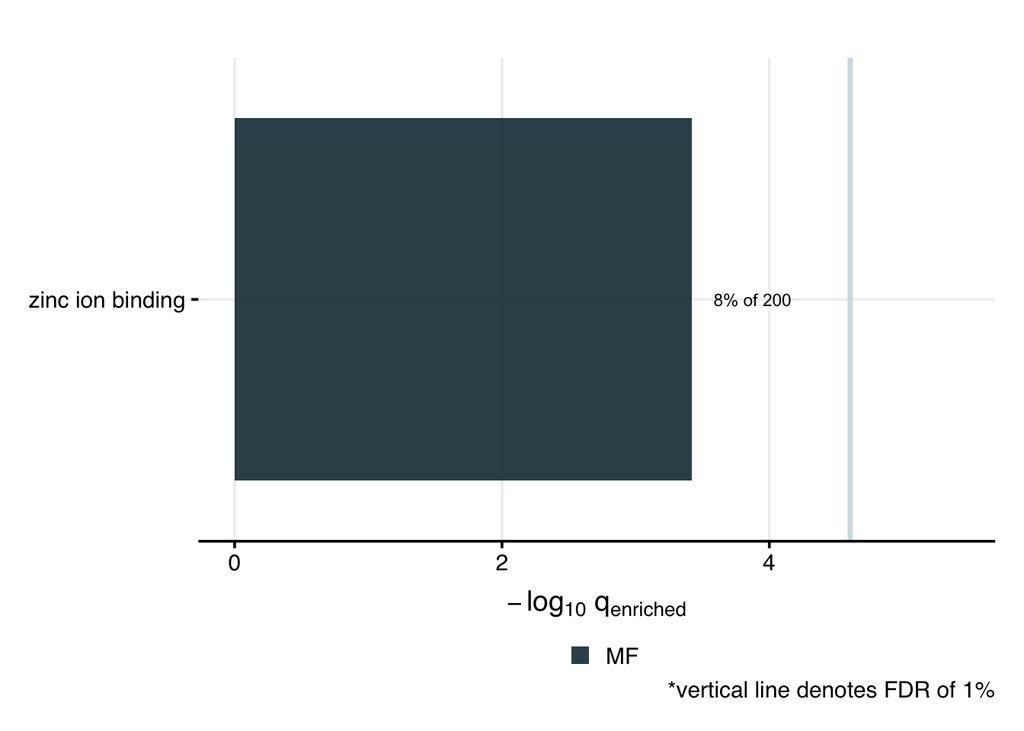

```r
# cluster 3
# rhy.8.cluster.3 <-
  my_gene_col[[3]] %>%
  rownames_to_column(var = "gene") %>%
  filter(cluster %in% c(3)) %>%
  pull(gene) %>%
  # run enrichment analysis
  go_enrichment(.,
                function.dir = path_to_repo,
                org = "cflo",
                bg = expressed) %>%  # enrichment against all expressed ophio_cflo genes
  go_enrichment_plot(clean = "no",
                   function.dir = path_to_repo)
```